# Case study 1:The Heliotronics Case

Oscar Wieland, Pablo Huber

2024-03-07

#### Preparation

```r
rm(list = ls()) #Clean the entire environment
cat("\014") # clean console
```

```r
setwd("~/Desktop/Master-Business analytics/Spring semester/Advanced Data Driven/Case study/Case study 1")
```

##### Install required packages

```r
# install.packages('dplyr')
# install.packages('lm.beta')
```

#### Import required packages

```r
## set library
library(prettydoc) # for the theme
library(dplyr)
library(ggplot2)
library(lm.beta)
library(data.table)
```

## Context

A widely known notion in our society is that through repetition of a task, one should experience increased productivity and enhancement for subsequent executions of the same task. This concept can be expressed mathematically using the formula: $Y = AX^b$, where in our case:  
Y = the average manufacturing cost of the last batch of 100 solar panels in $  
A = the price of the first unit.  
X = the total number of solar panels produced  
b = the experience parameter

In the industry context, this means that the cost of manufacturing or installing a unit should decrease as the total number of units manufactured increases.

This can be modeled with the experience curve as it describes the decreasing cost associated with increased experience, quantified by the accumulated output achieved.

## Our goal

We have been contacted by Mr Clayton Handleman, the CEO of Heliotronics, a solar panels company. He desires to participate in a project initiated by the Canton of Tessin, which aims to install 400 solar panels by June 2022. To do so, he contacted us to find a competitive price that would allow him to do better than his competitors. Knowing about the experience curve and by being aware that by the time Heliotronics begins production of the 400 solar panels, an additional 2400 solar panels will have already been produced, we can anticipate a decrease in the production cost per unit. Thus, we should provide Mr Handleman an estimate about the average manufacturing cost for the last 400 panels.

We received data of the evolution of the average manufacturing cost per batch of solar panel since heliotronics started production a few years ago.

```r
Hdata = read.csv("Case_Stud_ I.csv")
Hdata
```

```
##    number_of_solar_panels manufacturing_cost
## 1                     100             1250.0
## 2                     200             1108.7
## 3                     300             1053.5
## 4                     400             1033.4
## 5                     500              989.8
## 6                     600              999.0
## 7                     700              914.9
## 8                     800              931.0
## 9                     900              922.3
## 10                   1000              861.9
## 11                   1100              820.9
## 12                   1200              823.2
## 13                   1300              876.7
## 14                   1400              817.2
## 15                   1500              837.2
## 16                   1600              815.3
## 17                   1700              804.6
## 18                   1800              765.3
## 19                   1900              820.6
## 20                   2000              828.1
## 21                   2100              765.2
## 22                   2200              784.5
```

```r
summary(Hdata)
```

```
##  number_of_solar_panels manufacturing_cost
##  Min.   : 100           Min.   : 765.2
##  1st Qu.: 625           1st Qu.: 818.0
##  Median :1150           Median : 849.5
##  Mean   :1150           Mean   : 901.1
##  3rd Qu.:1675           3rd Qu.: 975.1
##  Max.   :2200           Max.   :1250.0
```

## Question 1

Let’s make a scatter plot:

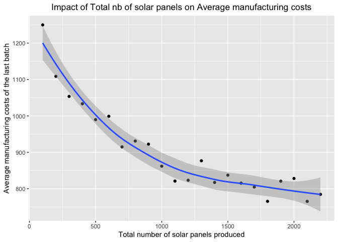

```r
ggplot(Hdata, aes(number_of_solar_panels, manufacturing_cost) ) +
  ggtitle("Impact of Total nb of solar panels on Average manufacturing costs") +
  xlab("Total number of solar panels produced") +
  ylab("Average manufacturing costs of the last batch") +
  theme(plot.title = element_text(hjust = 0.5)) +
  geom_point() +
  geom_smooth()
```

As we can see, a linear trend is not apparent. Instead, the data follow the multiplicative learning model $Y=AX^b$.This experience curve illustrates a decrease in the manufacturing cost per batch as the total quantity manufactured increase. Unfortunately, this is not a linear relationship that a regression analysis can model.

Thus, we will transform the data in order to have a linear relationship. To do so, we make a logarithmic transformation:
$$Y=AX^b \implies log(Y)=log(A)+b*log(X)$$
We will transform the variables and add them to our table:

```r
Hdata = Hdata %>%
  mutate(Log_number_of_solar_panels= log(number_of_solar_panels))
Hdata = Hdata %>%
  mutate(Log_manufacturing_cost= log(manufacturing_cost))
```

We can remake the scatterplot:

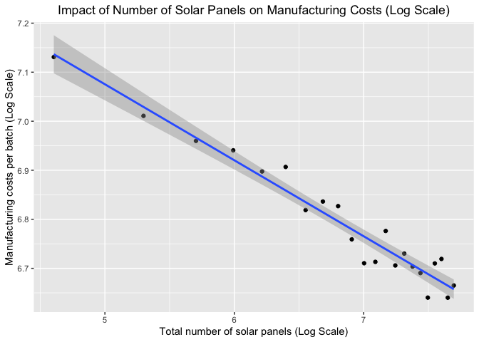

```r
ggplot(Hdata, aes(Log_number_of_solar_panels, Log_manufacturing_cost)) +
  ggtitle("Impact of Number of Solar Panels on Manufacturing Costs (Log Scale)") +
  xlab("Total number of solar panels (Log Scale)") +
  ylab("Manufacturing costs per batch (Log Scale)") +
  theme(plot.title = element_text(hjust = 0.5)) +
  geom_point()+
    geom_smooth(method="lm")
```

Now we have a linear relationship which is represented by a straight line.

## Question 2

It’s interesting to conduct a linear regression with the transformed data. Here is the estimated regression model:

```r
Model=with(Hdata,lm(Log_manufacturing_cost~Log_number_of_solar_panels))

summary(lm.beta(Model))
```

```
##
## Call:
## lm(formula = Log_manufacturing_cost ~ Log_number_of_solar_panels)
##
## Residuals:
##       Min        1Q    Median        3Q       Max
## -0.054515 -0.019960 -0.004477  0.021216  0.047893
##
## Coefficients:
##                             Estimate Standardized Std. Error t value Pr(>|t|)
## (Intercept)                 7.850325           NA   0.054409  144.28  < 2e-16
## Log_number_of_solar_panels -0.154991    -0.974768   0.007936  -19.53  1.7e-14
##
## (Intercept)                ***
## Log_number_of_solar_panels ***
## ---
## Signif. codes:  0 '***' 0.001 '**' 0.01 '*' 0.05 '.' 0.1 ' ' 1
##
## Residual standard error: 0.0299 on 20 degrees of freedom
## Multiple R-squared:  0.9502, Adjusted R-squared:  0.9477
## F-statistic: 381.4 on 1 and 20 DF,  p-value: 1.701e-14
```

The F-statistic is large and it’s p-value is small which means the model is (overall) statistically significant.

there is a high multiple R-squared and a high Adjusted R-squared. It means that a large proportion (94.77%) of the variability in the dependent variable is explained by the independent variable in the regression model. It suggests that the model fits the data well and that the independent variable is a good predictor of the dependent variable.

The variable “Log_number_of_solar_panels” and the intercept have a very small p-value which means that both coefficients are significantly different from zero. It allows us to infer that if the variable change it leads to a corresponding change in the outcome. In this case, log(A) is 7.850325 and b is -0.154991. But how can we interpret these coefficients ? Be careful, we are dealing with a logarithmic transformation so we cannot rely on a one-for-one relationship (When X increase by 1, Y increase also by 1) as the logarithmic transformation alters the relationship. We are dealing with a log-log model. Thus, when the number of solar panels increase by 1%, the manufacturing costs decrease by 0.154991%.

We can write the regression as:
$$log(Y)=7.850325 - 0.154991*log(X)$$

It is also interesting to know the learning rate. It can be defined as:  
1 - Progress ratio, where the progress ratio = $\frac{Y_{2x}}{Y_{x}}$

Let’s develop the components of the progress ratio: First we have to find $Y_{2x}$
$$Log(Y_{2x}) = Log(A) + b*Log(2X) \\
\implies Log(Y_{2x}) - b*Log(2X) = Log(A) \implies Log(Y_{2x}) -
Log((2X)^b) = Log(A) \\
\implies Log(\frac{Y_{2x}}{(2X)^{b}}) = Log(A)\implies
\frac{Y_{2x}}{(2X)^{b}}= A \\
\implies Y_{2x}=A2^bX^b$$

We have also to find $Y_{x}$. It is the same procedure as before:
$$Log(Y_{x}) = Log(A) + b*Log(X) \\
\implies Log(Y_{x}) - b*Log(X) = Log(A)\\
\implies Log(Y_{x}) - Log(X^b) = Log(A) \\
\implies Log(\frac{Y_{x}}{X^{b}}) = Log(A) \implies
\frac{Y_{x}}{X^{b}}= A \\
\implies Y_{x}=AX^b$$

Thus, the progress ratio:
$$\frac{Y_{2x}}{Y_{x}} = \frac{A*(2X)^{b}}{A*X^{b}} = 2^{b}$$
Finally, the learning rate is: Learning rate = 1 - Process ratio = $1 - 2^{b}$

```r
Learning_rate = 1 - 2^(-0.154991)
Learning_rate
```

```
## [1] 0.101862
```

The learning rate is 10.1862%.

## Question 3

Now that we have estimated the experience curve using the regression model, we can determine the expected average manufacturing cost per solar panel for the last 400 solar panels. It’s important to note that an additional 2400 solar panels will be produced meanwhile. Consequently, the total production volume will reach 4600 units by the time the new 400 solar panels are added. The new 400 solar panels will thus be numbered as follows: 4700, 4800, 4900, and 5000.

As our estimates have been created with a log-log model. It should be interesting to go back to the model in order to have real value and be able to interpret the average manufacturing costs.

$$log(Y) = log(A) + b*log(X) \\
\implies e^{log(Y)}=e^{(log(A)+b \cdot log(X))} \\
\implies e^{log(Y)}=e^{log(A)}*e^{b \cdot log(X)} \\
\implies Y= Ae^{b \cdot log(X)} \\
\implies Y=AX^b$$

```r
A = exp(7.850325)
b = - 0.154991
print(paste("A =", A))
```

```
## [1] "A = 2566.56831600529"
```

```r
print(paste("b = ", b))
```

```
## [1] "b =  -0.154991"
```

So we have:
$$Y = 2566.568*X^{-0.154991}$$

```r
Hdata2 = Hdata[,1:2]
```

We created a for-loop that complete the table using the formula $Y = 2566.568*X^{-0.154991}$:

```r
library(data.table)
for (i in seq(2300, 5000, 100)){
  new_row = data.frame(number_of_solar_panels=i, manufacturing_cost=A*i^{b})
  Hdata2 = rbind(Hdata2, new_row)
}
```

This is the resulting table with all the manufacturing costs for the solar panels made after 2200:

```r
Hdata2
```

```
##    number_of_solar_panels manufacturing_cost
## 1                     100          1250.0000
## 2                     200          1108.7000
## 3                     300          1053.5000
## 4                     400          1033.4000
## 5                     500           989.8000
## 6                     600           999.0000
## 7                     700           914.9000
## 8                     800           931.0000
## 9                     900           922.3000
## 10                   1000           861.9000
## 11                   1100           820.9000
## 12                   1200           823.2000
## 13                   1300           876.7000
## 14                   1400           817.2000
```

[output cut: 36 more lines]

Here is the plot the predicted average manufacturing costs:

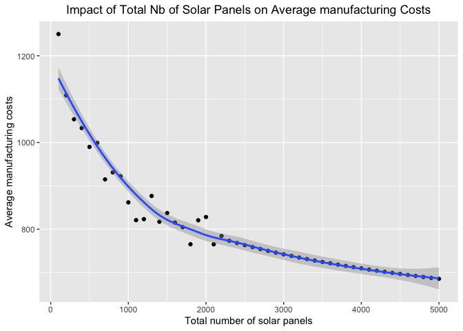

```r
ggplot(Hdata2, aes(number_of_solar_panels, manufacturing_cost) ) +
  ggtitle("Impact of Total Nb of Solar Panels on Average manufacturing Costs") +
  xlab("Total number of solar panels") +
  ylab("Average manufacturing costs") +
  theme(plot.title = element_text(hjust = 0.5)) +
  geom_point() +
  geom_smooth()
```

Finally, to have an idea of the expected average manufacturing cost per solar panel for the 400 solar panels that would be produced we took the mean of the manufacturing costs for the last 400 panels:

```r
production = Hdata2[47:50,]
production
```

```
##    number_of_solar_panels manufacturing_cost
## 47                   4700           692.1667
## 48                   4800           689.9118
## 49                   4900           687.7105
## 50                   5000           685.5605
```

```r
mean_avg_c = mean(production$manufacturing_cost)
mean_avg_c
```

```
## [1] 688.8374
```

The Average cost of the last 400 panels is: 688.837366146509

## Question 4

Finally, we can calculate a 95% confidence interval for the average manufacturing cost per solar panel for the panels produced for Tessin by using the lower and upper bounds of the confidence interval estimate for the experience parameter.

```r
CI=confint(Model)
CI
```

```
##                                 2.5 %     97.5 %
## (Intercept)                 7.7368307  7.9638202
## Log_number_of_solar_panels -0.1715456 -0.1384356
```

To do so, we created a for-loop that generates the lower and upper bounds of the confidence interval for each manufacturing cost ranging from 4700 to 5000 solar panels.

```r
t_alpha = qnorm(0.975)
library(data.table)


CI95 <- data.table(
    Mean = numeric(0),
    Lower_bound = numeric(0),
    Upper_bound = numeric(0)
)

for (i in seq(47, 50, 1)){
  new_row = data.frame(
    Mean=Hdata2[i,"manufacturing_cost"],
    Lower_bound=exp(CI[1,1])*(Hdata2[i,"number_of_solar_panels"]^CI[2,1]),
    Upper_bound=exp(CI[1,2])*(Hdata2[i,"number_of_solar_panels"]^CI[2,2])
  )
  CI95 = rbind(CI95, new_row)
}
```

```r
CI95
```

```
##        Mean Lower_bound Upper_bound
## 1: 692.1667    537.1934    891.8544
## 2: 689.9118    535.2568    889.2588
## 3: 687.7105    533.3668    886.7241
## 4: 685.5605    531.5215    884.2476
```

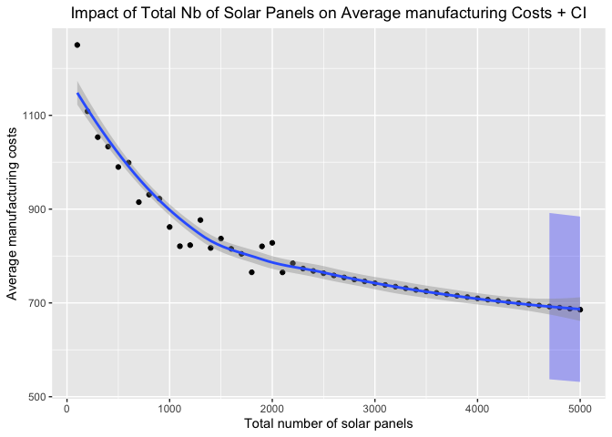

```r
Hdata2 = as.data.table(Hdata2)
Hdata2[, row_num := .I]
CI95[, row_num := 47:50]

merged = merge(Hdata2, CI95,by="row_num", all.x=TRUE)


ggplot(merged, aes(number_of_solar_panels, manufacturing_cost) ) +
  ggtitle("Impact of Total Nb of Solar Panels on Average manufacturing Costs + CI") +
  xlab("Total number of solar panels") +
  ylab("Average manufacturing costs") +
  theme(plot.title = element_text(hjust = 0.5)) +
  geom_point() +
  geom_ribbon(aes(ymin = Lower_bound, ymax = Upper_bound), alpha = 0.3, fill = "blue") +
  geom_smooth()
```

Then we took the mean of the lower bound and upper:

```r
LowerB = mean(CI95$Lower_bound)
UpperB = mean(CI95$Upper_bound)
```

The lower bound is: 534.334635196834  
The upper bound is: 888.021205058857

## Conclusion

Helitronics should take into account this experience curve and propose a price around 688. If they think the price is too high and take the bet that their average manufacturing cost will be closer, they can set a price between 688 and the lower bond. If they think the other competitors will set a price much higher, they can also propose a price between 688 and the upper bond to maximize profit.